# Supervised Learning with Fuzzy Logic

### Context

In this example, we leverage fuzzy logic for supervised learning in a classification task. The provided code snippet serves as an example for the integration of fuzzy logic within JAX to tackle explicit labeled data.

### Fuzzy Logic in Action

The fuzzy system, at the heart of this application, processes inputs through fuzzy membership functions. Domain logic is implemented using fuzzy AND, OR, and NOT operations, reflecting the imprecision and uncertainty often present in real-world decision-making.

### De-Fuzzification and Optimization

A crucial step in the process is de-fuzzification, where the fuzzy output values are converted into probabilities. This output is then harnessed to optimize thresholds, fine-tuning the fuzzy logic system.

### Training and Evaluation

The training process is no different from any other Equinox model. The provided classification report showcases the effectiveness of the fuzzy logic system in categorizing penguin species.

### Model Interpretation

Visualizing the fuzzy parameters further enhances our understanding of the model. The fuzzy membership functions for various features, such as body mass, flipper length, and culmen depth, provide insights into how the model interprets and classifies different penguin species.

```python
from itertools import chain
import sys
import os

from sklearn.metrics import classification_report
import numpy as np
import equinox as eqx
import jax
from tqdm import tqdm
import pandas as pd
import matplotlib.pyplot as plt

sys.path.append(os.path.dirname(__file__)+ '/../src')

from jazzy import (
    fuzzy_not,
    fuzzy_and,
    fuzzy_or,
    gt_fuzzifier,
    lt_fuzzifier,
    FuzzyParams,
    plot_fuzzy_gt,
    plot_fuzzy_lt,
)
```

```python
class FuzzyPenguinClassifier(eqx.Module):
    is_heavy_params: FuzzyParams
    has_long_flipper_params: FuzzyParams
    has_deep_culmen_params: FuzzyParams
    has_short_culmen_params: FuzzyParams

    def __init__(
        self,
        *,
        key,
    ) -> None:
        h_key, f_key, c_key, cl_key = jax.random.split(key, 4)
        self.is_heavy_params = FuzzyParams.initialize(key=h_key)
        self.has_long_flipper_params = FuzzyParams.initialize(key=f_key)
        self.has_deep_culmen_params = FuzzyParams.initialize(key=c_key)
        self.has_short_culmen_params = FuzzyParams.initialize(key=cl_key)

    def __call__(self, x):
        culmen_length, culmen_depth, flipper_length, body_mass = x

        is_heavy = gt_fuzzifier(body_mass, self.is_heavy_params)
        has_long_flipper = gt_fuzzifier(flipper_length, self.has_long_flipper_params)
        has_deep_culmen = gt_fuzzifier(culmen_depth, self.has_deep_culmen_params)
        has_short_culmen = lt_fuzzifier(culmen_length, self.has_short_culmen_params)

        is_gentoo = fuzzy_and(fuzzy_or(has_deep_culmen, is_heavy), has_long_flipper)
        is_adelie = fuzzy_and(fuzzy_not(is_gentoo), has_short_culmen)
        is_chinstrap = fuzzy_and(fuzzy_not(is_gentoo), fuzzy_not(is_adelie))

        indics = jax.numpy.stack((is_adelie, is_chinstrap, is_gentoo))
        return indics / indics.sum()
```

```python
def loss_fn(model, x, y, regu_weight=10):
    y_hat = jax.vmap(model)(x)
    bce = y * jax.numpy.log(y_hat + 1e-8) + (1 - y) * jax.numpy.log(1 - y_hat + 1e-8)
    sharpness = (
        model.is_heavy_params.sharpness
        + model.has_long_flipper_params.sharpness
        + model.has_deep_culmen_params.sharpness
        + model.has_short_culmen_params.sharpness
    )
    return jax.numpy.mean(-bce) + regu_weight / sharpness


grad_loss = jax.jit(jax.grad(loss_fn))
loss = jax.jit(loss_fn)


@jax.jit
def train_step(fuzzifier, x_test, y_test, learning_rate, regu_weight):
    y_hat = jax.vmap(fuzzifier)(x_test)
    loss_step = loss(fuzzifier, x_test, y_test, regu_weight)
    grads = grad_loss(fuzzifier, x_test, y_test)
    new_fuzzifier = jax.tree_map(lambda m, g: m - learning_rate * g, fuzzifier, grads)
    return y_hat, loss_step, grads, new_fuzzifier
```

```python
penguins_df = pd.read_csv("penguins_size.csv")

X = penguins_df[
    ["culmen_length_mm", "culmen_depth_mm", "flipper_length_mm", "body_mass_g"]
]
y = pd.get_dummies(penguins_df["species"])[["Adelie", "Chinstrap", "Gentoo"]]

is_train = ((pd.util.hash_array(penguins_df.index.values) % 100) / 100) > 0.2

X_train, X_test = X[is_train], X[~is_train]
y_train, y_test = y[is_train], y[~is_train]

X_train_mean = X_train.mean()

X_test = ((X_test - X_train.mean()) / X_train.std()).fillna(0)
X_train = ((X_train - X_train.mean()) / X_train.std()).fillna(0)
```

```python
clf = FuzzyPenguinClassifier(key=jax.random.PRNGKey(123))

print(clf(X_train.iloc[0]))
```

```
WARNING:absl:No GPU/TPU found, falling back to CPU. (Set TF_CPP_MIN_LOG_LEVEL=0 and rerun for more info.)
```

```
[0.49506804 0.28895313 0.21597885]
```

```python
history = {"epoch": [], "loss": [], "grad_l1": [], "grad_linf": []}

learning_rate = 0.1
regu_weight = 10

for epoch in tqdm(list(range(5000))):
    y_hat, loss_step, grads, clf = train_step(
        clf, X_train.values, y_train.values, learning_rate, regu_weight
    )
    flat_grads = list(chain(*grads.tree_flatten()[0]))
    history["epoch"].append(epoch)
    history["loss"].append(loss_step)
    history["grad_l1"].append(sum(abs(g) for g in flat_grads) / len(flat_grads))
    history["grad_linf"].append(max(g for g in flat_grads))
```

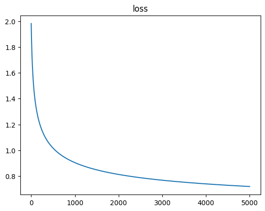

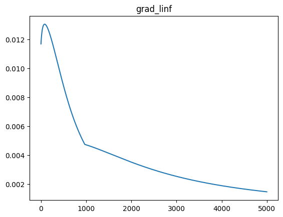

```python
plt.plot(history["epoch"], history["loss"])
plt.title("loss")
plt.figure()
plt.plot(history["epoch"], history["grad_linf"])
plt.title("grad_linf")
```

```python
preds = jax.vmap(clf)(X_test.values)

print(
    classification_report(
        np.argmax(y_test.values, axis=1),
        np.argmax(preds, axis=1),
        target_names=y_test.columns,
    )
)
```

```
              precision    recall  f1-score   support

      Adelie       0.71      1.00      0.83        34
   Chinstrap       1.00      0.27      0.42        15
      Gentoo       0.96      0.86      0.91        28

    accuracy                           0.81        77
   macro avg       0.89      0.71      0.72        77
weighted avg       0.86      0.81      0.78        77
```

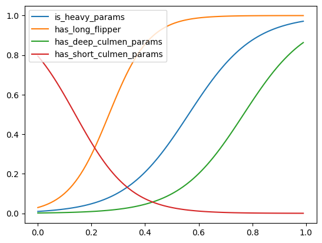

```python
plot_fuzzy_gt(
    [i / 100 for i in range(100)], clf.is_heavy_params, label="is_heavy_params"
)
plot_fuzzy_gt(
    [i / 100 for i in range(100)], clf.has_long_flipper_params, label="has_long_flipper"
)
plot_fuzzy_gt(
    [i / 100 for i in range(100)],
    clf.has_deep_culmen_params,
    label="has_deep_culmen_params",
)
plot_fuzzy_lt(
    [i / 100 for i in range(100)],
    clf.has_short_culmen_params,
    label="has_short_culmen_params",
)

plt.legend()
plt.figure()
```